# Red neuronal: aprendizaje profundo

Félix R. Millán Trujillo

2020

En este documento se entrenará y evaluará una red neuronal de aprendizaje profundo. Para ello, se utilizará la base de datos **College** de la biblioteca **ISLR**. Esta base de datos consta de 18 variables, para un total de 777 observaciones. Se trata de predecir la procedencia de una institución pública o privada, como función de una serie de variables inherentes a las distintas instituciones universitarias consideradas. El proceso de diseño, entrenamiento y evaluación de la red neuronal se llevará a cabo en tres etapas:

- Preparación de los datos
- Entrenamiento de la red
- Evaluación de la capacidad predictiva

### Preparación de los datos

En primer lugar, especificamos las librerías a utilizar: **ISLR** y **neuralnet** y definimos como datos crudos (**crude_data**), la base de datos **College**. la función **head** permite visualizar las seis primeras filas de la estructura de datos, en tanto que la función **str**, muestra la naturaleza de cada variable.

```r
library(ISLR)
library(neuralnet)
crude_data = College
head(crude_data)
```

```
##                              Private Apps Accept Enroll Top10perc Top25perc
## Abilene Christian University     Yes 1660   1232    721        23        52
## Adelphi University               Yes 2186   1924    512        16        29
## Adrian College                   Yes 1428   1097    336        22        50
## Agnes Scott College              Yes  417    349    137        60        89
## Alaska Pacific University        Yes  193    146     55        16        44
## Albertson College                Yes  587    479    158        38        62
##                              F.Undergrad P.Undergrad Outstate Room.Board Books
## Abilene Christian University        2885         537     7440       3300   450
## Adelphi University                  2683        1227    12280       6450   750
## Adrian College                      1036          99    11250       3750   400
## Agnes Scott College                  510          63    12960       5450   450
## Alaska Pacific University            249         869     7560       4120   800
## Albertson College                    678          41    13500       3335   500
##                              Personal PhD Terminal S.F.Ratio perc.alumni Expend
## Abilene Christian University     2200  70       78      18.1          12   7041
## Adelphi University               1500  29       30      12.2          16  10527
## Adrian College                   1165  53       66      12.9          30   8735
## Agnes Scott College               875  92       97       7.7          37  19016
## Alaska Pacific University        1500  76       72      11.9           2  10922
## Albertson College                 675  67       73       9.4          11   9727
##                              Grad.Rate
## Abilene Christian University        60
## Adelphi University                  56
## Adrian College                      54
## Agnes Scott College                 59
## Alaska Pacific University           15
## Albertson College                   55
```

```r
str(crude_data)
```

```
## 'data.frame':    777 obs. of  18 variables:
##  $ Private    : Factor w/ 2 levels "No","Yes": 2 2 2 2 2 2 2 2 2 2 ...
##  $ Apps       : num  1660 2186 1428 417 193 ...
##  $ Accept     : num  1232 1924 1097 349 146 ...
##  $ Enroll     : num  721 512 336 137 55 158 103 489 227 172 ...
##  $ Top10perc  : num  23 16 22 60 16 38 17 37 30 21 ...
##  $ Top25perc  : num  52 29 50 89 44 62 45 68 63 44 ...
##  $ F.Undergrad: num  2885 2683 1036 510 249 ...
##  $ P.Undergrad: num  537 1227 99 63 869 ...
##  $ Outstate   : num  7440 12280 11250 12960 7560 ...
##  $ Room.Board : num  3300 6450 3750 5450 4120 ...
##  $ Books      : num  450 750 400 450 800 500 500 450 300 660 ...
##  $ Personal   : num  2200 1500 1165 875 1500 ...
##  $ PhD        : num  70 29 53 92 76 67 90 89 79 40 ...
##  $ Terminal   : num  78 30 66 97 72 73 93 100 84 41 ...
##  $ S.F.Ratio  : num  18.1 12.2 12.9 7.7 11.9 9.4 11.5 13.7 11.3 11.5 ...
##  $ perc.alumni: num  12 16 30 37 2 11 26 37 23 15 ...
##  $ Expend     : num  7041 10527 8735 19016 10922 ...
##  $ Grad.Rate  : num  60 56 54 59 15 55 63 73 80 52 ...
```

La primera variable (**Private**), será la variable dependiente que está en función de las 17 variables restantes. Nótese que es un factor y dado que la red neuronal es un modelo matemático, todas las variables deben ser numéricas, por lo que es necesario transformar el factor **Private** en una variable numérica

```r
private <- as.numeric(crude_data$Private)
```

Reestructuramos de nuevo la base de datos con la función **cbind**

```r
data <- cbind(private,crude_data[2:18])
str(data)
```

```
## 'data.frame':    777 obs. of  18 variables:
##  $ private    : num  2 2 2 2 2 2 2 2 2 2 ...
##  $ Apps       : num  1660 2186 1428 417 193 ...
##  $ Accept     : num  1232 1924 1097 349 146 ...
##  $ Enroll     : num  721 512 336 137 55 158 103 489 227 172 ...
##  $ Top10perc  : num  23 16 22 60 16 38 17 37 30 21 ...
##  $ Top25perc  : num  52 29 50 89 44 62 45 68 63 44 ...
##  $ F.Undergrad: num  2885 2683 1036 510 249 ...
##  $ P.Undergrad: num  537 1227 99 63 869 ...
##  $ Outstate   : num  7440 12280 11250 12960 7560 ...
##  $ Room.Board : num  3300 6450 3750 5450 4120 ...
##  $ Books      : num  450 750 400 450 800 500 500 450 300 660 ...
##  $ Personal   : num  2200 1500 1165 875 1500 ...
##  $ PhD        : num  70 29 53 92 76 67 90 89 79 40 ...
##  $ Terminal   : num  78 30 66 97 72 73 93 100 84 41 ...
##  $ S.F.Ratio  : num  18.1 12.2 12.9 7.7 11.9 9.4 11.5 13.7 11.3 11.5 ...
##  $ perc.alumni: num  12 16 30 37 2 11 26 37 23 15 ...
##  $ Expend     : num  7041 10527 8735 19016 10922 ...
##  $ Grad.Rate  : num  60 56 54 59 15 55 63 73 80 52 ...
```

Ahora, **todas las variables son numéricas**. Dado que los números que componen el **dataframe** son apreciablemente disímiles, es conveniente y necesario normalizar los datos, a fin de facilitar la convergencia de la red durante el entrenamiento. La normalización se hará con el método de máximos y mínimos, de acuerdo a la ecuación:

$$x_{normalizado}=\frac{x-x_{mínimo}}{x_{máximo}-x_{mínimo}}$$

En el siguiente bloque, se definirá la función previamente especificada y se aplicará con la función **sapply** a la base de datos

```r
normalize <- function(x){
    (x-min(x))/(max(x)-min(x))
}
normalized_data <- sapply(data, FUN = normalize)
head(normalized_data)
```

```
##      private        Apps      Accept      Enroll Top10perc Top25perc
## [1,]       1 0.032886926 0.044177013 0.107912537 0.2315789 0.4725275
## [2,]       1 0.043842293 0.070530886 0.075035394 0.1578947 0.2197802
## [3,]       1 0.028054902 0.039035722 0.047349379 0.2210526 0.4505495
## [4,]       1 0.006998105 0.010549166 0.016045304 0.6210526 0.8791209
## [5,]       1 0.002332702 0.002818189 0.003146138 0.1578947 0.3846154
## [6,]       1 0.010538812 0.015500038 0.019348749 0.3894737 0.5824176
##      F.Undergrad P.Undergrad  Outstate Room.Board     Books   Personal
## [1,]  0.08716353 0.024547744 0.2634298  0.2395965 0.1577540 0.29770992
## [2,]  0.08075165 0.056148386 0.5134298  0.7361286 0.2914439 0.19083969
## [3,]  0.02847257 0.004488207 0.4602273  0.3105296 0.1354724 0.13969466
## [4,]  0.01177628 0.002839478 0.5485537  0.5784994 0.1577540 0.09541985
## [5,]  0.00349162 0.039752691 0.2696281  0.3688525 0.3137255 0.19083969
## [6,]  0.01710894 0.001831921 0.5764463  0.2451135 0.1800357 0.06488550
##            PhD   Terminal S.F.Ratio perc.alumni    Expend Grad.Rate
## [1,] 0.6526316 0.71052632 0.4182306    0.187500 0.0726714 0.4629630
## [2,] 0.2210526 0.07894737 0.2600536    0.250000 0.1383867 0.4259259
## [3,] 0.4736842 0.55263158 0.2788204    0.468750 0.1046053 0.4074074
## [4,] 0.8842105 0.96052632 0.1394102    0.578125 0.2984146 0.4537037
## [5,] 0.7157895 0.63157895 0.2520107    0.031250 0.1458329 0.0462963
## [6,] 0.6210526 0.64473684 0.1849866    0.171875 0.1233057 0.4166667
```

Ahora, toda la información numérica del **dataframe** oscila entre 0 y 1; esto, facilitará el entrenamiento y la convergencia, como se mencionó con anterioridad.

El proceso de diseñar una red neuronal, consta de una etapa de entrenamiento y otra de evaluación de la habilidad predictiva. Generalmente podemos utilizar el 70% de la base de datos para el entrenamiento y el 30% para la evaluación (70:30). Para ello, se tomará una muestra aleatoria con la función **sample** y los datos normalizados se dividirán en dos conjuntos.

```r
sample <- sample(1:nrow(data),round(0.70*nrow(data)))
sample
```

[output not shown]

[output cut: 16 more lines]

El tamaño de muestra para el entrenamiento es de

```r
0.70*777
```

```
## [1] 543.9
```

como se puede constatar en el bloque anterior y dado que se utilizó la función **round**, el tamaño de muestra fue de 544 observaciones. A continuación se definirán los objetos de entrenamiento y evaluación, con los nombres **training_data** y **test_data**, respectivamente

```r
training_data <- as.data.frame(normalized_data[sample,])
str(training_data)
```

```
## 'data.frame':    544 obs. of  18 variables:
##  $ private    : num  1 1 1 0 1 1 1 1 1 0 ...
##  $ Apps       : num  0.02947 0.03451 0.01781 0.02449 0.00975 ...
##  $ Accept     : num  0.0431 0.0495 0.0275 0.0331 0.0124 ...
##  $ Enroll     : num  0.0618 0.0601 0.0255 0.0516 0.0211 ...
##  $ Top10perc  : num  0.2632 0.2105 0.2421 0.0842 0.2632 ...
##  $ Top25perc  : num  0.527 0.505 0.516 0.143 0.462 ...
##  $ F.Undergrad: num  0.0479 0.038 0.0195 0.0447 0.0382 ...
##  $ P.Undergrad: num  0.04282 0.00133 0.00957 0.01342 0.08015 ...
##  $ Outstate   : num  0.545 0.833 0.46 0.275 0.357 ...
##  $ Room.Board : num  0.419 0.66 0.378 0.459 0.437 ...
##  $ Books      : num  0.144 0.269 0.113 0.135 0.147 ...
##  $ Personal   : num  0.0901 0.0916 0.2672 0.0687 0.1679 ...
##  $ PhD        : num  0.568 0.884 0.663 0.853 0.463 ...
##  $ Terminal   : num  0.579 0.947 0.618 0.882 0.447 ...
##  $ S.F.Ratio  : num  0.306 0.287 0.233 0.327 0.284 ...
##  $ perc.alumni: num  0.469 0.641 0.578 0.125 0.203 ...
##  $ Expend     : num  0.1059 0.3679 0.1297 0.059 0.0516 ...
##  $ Grad.Rate  : num  0.713 0.565 0.565 0.639 0.472 ...
```

```r
test_data <- as.data.frame(normalized_data[-sample,])
str(test_data)
```

```
## 'data.frame':    233 obs. of  18 variables:
##  $ private    : num  1 1 1 1 1 1 1 1 1 1 ...
##  $ Apps       : num  0.03289 0.04384 0.02805 0.00233 0.00567 ...
##  $ Accept     : num  0.04418 0.07053 0.03904 0.00282 0.01021 ...
##  $ Enroll     : num  0.10791 0.07504 0.04735 0.00315 0.0107 ...
##  $ Top10perc  : num  0.232 0.158 0.221 0.158 0.168 ...
##  $ Top25perc  : num  0.473 0.22 0.451 0.385 0.396 ...
##  $ F.Undergrad: num  0.08716 0.08075 0.02847 0.00349 0.00879 ...
##  $ P.Undergrad: num  0.02455 0.05615 0.00449 0.03975 0.01049 ...
##  $ Outstate   : num  0.263 0.513 0.46 0.27 0.566 ...
##  $ Room.Board : num  0.24 0.736 0.311 0.369 0.621 ...
##  $ Books      : num  0.158 0.291 0.135 0.314 0.18 ...
##  $ Personal   : num  0.298 0.191 0.14 0.191 0.191 ...
##  $ PhD        : num  0.653 0.221 0.474 0.716 0.863 ...
##  $ Terminal   : num  0.7105 0.0789 0.5526 0.6316 0.9079 ...
##  $ S.F.Ratio  : num  0.418 0.26 0.279 0.252 0.241 ...
##  $ perc.alumni: num  0.1875 0.25 0.4688 0.0312 0.4062 ...
##  $ Expend     : num  0.0727 0.1384 0.1046 0.1458 0.107 ...
##  $ Grad.Rate  : num  0.463 0.4259 0.4074 0.0463 0.4907 ...
```

Obsérvese los dos conjuntos, uno de 544 observaciones y otro de 233. Ya los datos han sido transformados y organizados, lo cual representa el mayor esfuerzo para el diseño de una red neuronal.

### Entrenamiento de la red neuronal

Antes de definir y entrenar la red, es necesario establecer la relación funcional entre las variables, de acuerdo al criterio mencionado al principio del documento

```r
f <- as.formula(private~Apps+Accept+Enroll+Top10perc+Top25perc+
                    F.Undergrad+P.Undergrad+Outstate+Room.Board+
                    Books+Personal+PhD+Terminal+S.F.Ratio+
                    perc.alumni+Expend+Grad.Rate)
f
```

```
## private ~ Apps + Accept + Enroll + Top10perc + Top25perc + F.Undergrad +
##     P.Undergrad + Outstate + Room.Board + Books + Personal +
##     PhD + Terminal + S.F.Ratio + perc.alumni + Expend + Grad.Rate
```

```r
deep_net <- neuralnet(f,data = training_data,hidden = c(6,5),
                      linear.output = FALSE)
plot(deep_net)
```

A continuación, se muestra la arquitectura neuronal de la red entrenada

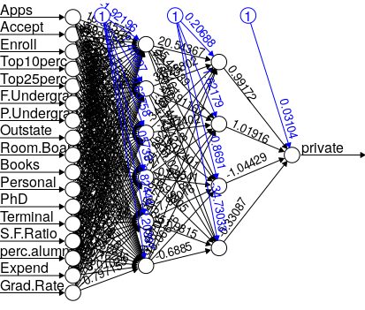

### Evaluación de la red

Procederemos ahora a evaluar el modelo neuronal. Crearemos para ello un objeto **predicted_data** y se utilizará la función **compute**.

```r
predicted_data <- compute(deep_net,test_data[,2:18])
head(predicted_data$net.result)
```

```
##              [,1]
## [1,] 1.857219e-06
## [2,] 1.000000e+00
## [3,] 1.000000e+00
## [4,] 1.000000e+00
## [5,] 1.000000e+00
## [6,] 1.000000e+00
```

Dado que los valores predichos por la red se muestran con decimales, se utilizará las funciones **sapply** y **round** para generar valores de 0 o 1, donde 1 significa proveniente de una escuela privada.

```r
predicted_data$net.result <- sapply(predicted_data$net.result,
                                    round, digits=0)
head(predicted_data$net.result)
```

```
## [1] 0 1 1 1 1 1
```

Se organizan los valores actuales y predichos en un **dataframe**

```r
results <- data.frame(Actual=test_data$private,
                 Predichos=predicted_data$net.result)
head(results)
```

```
##   Actual Predichos
## 1      1         0
## 2      1         1
## 3      1         1
## 4      1         1
## 5      1         1
## 6      1         1
```

Por último, se elabora una tabla de contingencia con la función **table** a partir de los valores actuales y predichos, a fin de determinar la precisión de la red

```r
cont_table <- table(results)
cont_table
```

```
##       Predichos
## Actual   0   1
##      0  53   8
##      1   4 168
```

Como se observa en la tabla de contingencia, a partir de los datos de evaluación (233), el modelo neuronal tiene una precisión superior al 90%. Puede probarse otra estructura neuronal, con más capas ocultas o más neuronas por capa oculta, a fin de incrementar la precisión de la red.